# STATS 326/786 — Lab 02 Q3(c) Model Answer

Week 2 Tutorial

# Problem 3 — Setup

Recreate the departure and arrival date-times from Q3(a) and Q3(b).

```r
data <- flights %>%
  filter(origin == "JFK",
         dest   == "LAX",
         !is.na(arr_time))

# Q3(a): actual departure date-time
data <- data %>%
  mutate(dep_datetime = time_hour + minutes(dep_delay))

# Q3(b): actual arrival date-time (US/Pacific), adjusted for overnight flights
data <- data %>%
  mutate(
    arr_time_char = sprintf("%04d", arr_time),
    arr_datetime  = make_datetime(
      year  = year,
      month = month,
      day   = day,
      hour  = as.numeric(substr(arr_time_char, 1, 2)),
      min   = as.numeric(substr(arr_time_char, 3, 4)),
      tz    = "US/Pacific"
    )
  ) %>%
  mutate(overnight    = arr_datetime < dep_datetime) %>%
  mutate(arr_datetime = arr_datetime + days(overnight))
```

# Problem 3(c)

> We are told that the average transit time is 6.5 hours. Create a variable to calculate the transit time, i.e., the difference between the arrival date-time and departure date-time. Plot the distribution and comment. Then plot the transit time against the air time and comment.

## Solution

### Calculate transit time

```r
data <- data %>%
  mutate(transit_time = arr_datetime - dep_datetime)
```

`arr_datetime - dep_datetime` returns a `difftime` object in hours (since both are `POSIXct` with different time zones, lubridate handles the UTC conversion automatically).

### Plot 1 — Distribution of transit time

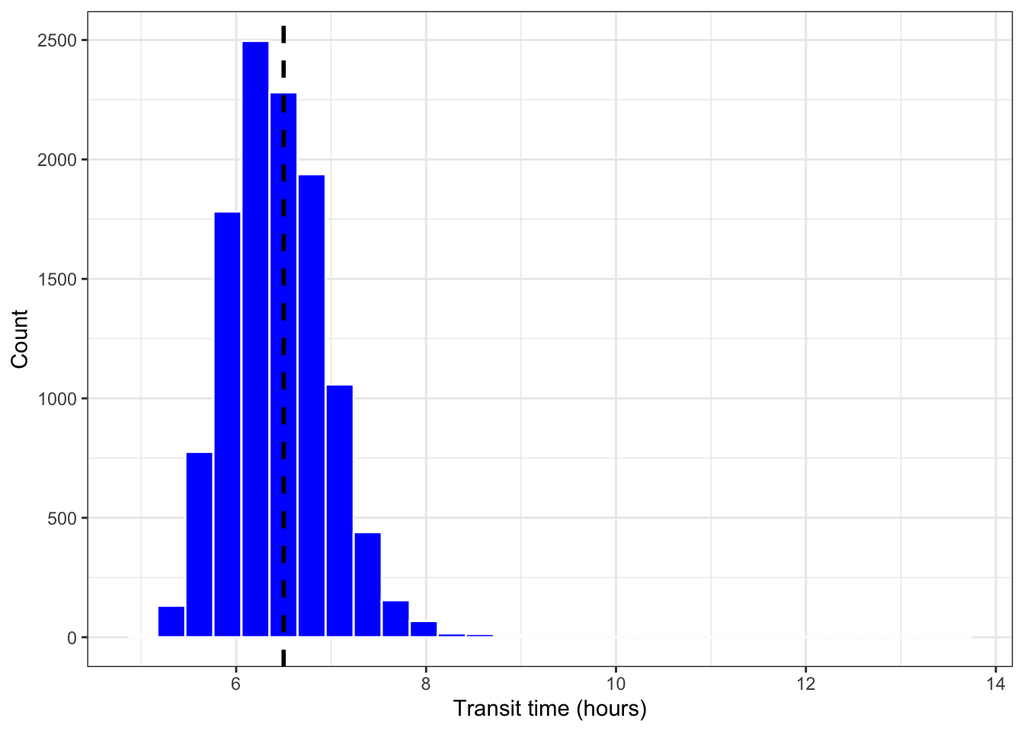

```r
ggplot(data = data,
       mapping = aes(x = transit_time)) +
  geom_histogram(fill = "blue", col = "white") +
  geom_vline(xintercept = 6.5, linewidth = 1, linetype = "dashed") +
  theme_bw() +
  labs(x = "Transit time (hours)",
       y = "Count")
```

**Comment:** The distribution of transit times is roughly unimodal and approximately symmetric, centred close to the claimed average of 6.5 hours (dashed line). The bulk of flights have transit times between about 5.5 and 7.5 hours. There is a small number of outliers with unusually long transit times, likely due to large arrival delays.

### Plot 2 — Transit time vs air time

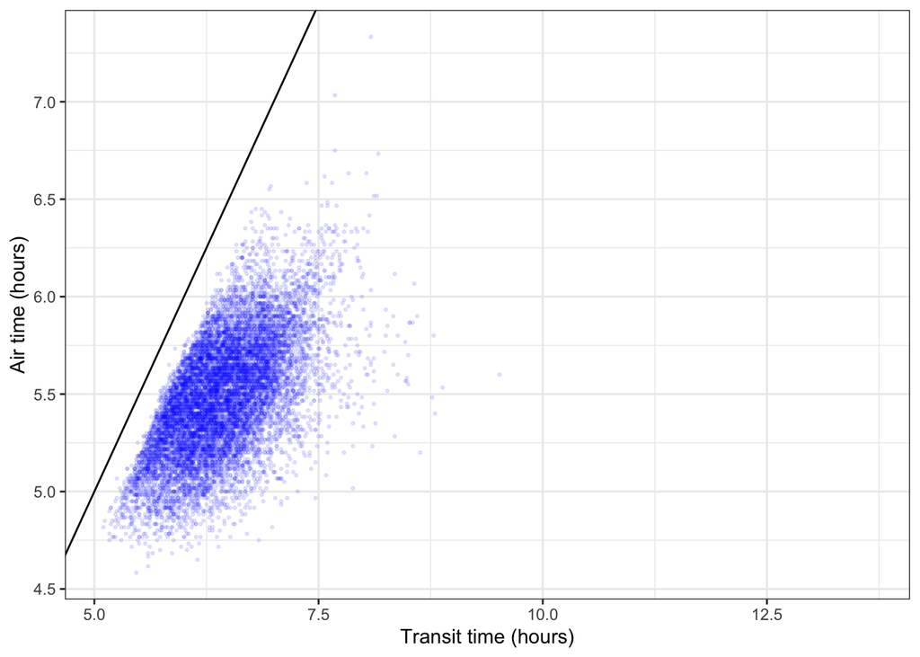

```r
ggplot(data = data,
       mapping = aes(x = transit_time,
                     y = air_time / 60)) +
  geom_point(alpha = 0.1, col = "blue", size = 0.5) +
  geom_abline(slope = 1, intercept = 0) +
  theme_bw() +
  labs(x = "Transit time (hours)",
       y = "Air time (hours)")
```

**Comment:** Transit time is always **greater** than air time — all points lie below the 45° reference line (slope = 1, intercept = 0). This is expected: `arr_time` in the dataset records when the aircraft arrives at the gate, not when it touches down, so transit time includes taxi time at both ends plus any time spent holding before landing. The two variables are strongly positively correlated, with the gap between them representing the ground/taxi component of the journey.